```python
# Library to suppress warnings or deprecation notes
import warnings
warnings.filterwarnings('ignore')

# Libraries to help with reading and manipulating data
import numpy as np
import pandas as pd

# Libraries to help with data visualization
import matplotlib.pyplot as plt
%matplotlib inline
import seaborn as sns

# Libraries to split data, impute missing values
from sklearn.model_selection import train_test_split
from sklearn.impute import SimpleImputer

# Libraries to import decision tree classifier and different ensemble classifiers
from sklearn.ensemble import BaggingClassifier
from sklearn.ensemble import RandomForestClassifier
from sklearn.ensemble import AdaBoostClassifier, GradientBoostingClassifier
!pip install xgboost
from xgboost import XGBClassifier
from sklearn.ensemble import StackingClassifier
from sklearn.tree import DecisionTreeClassifier

# Libtune to tune model, get different metric scores
from sklearn import metrics
from sklearn.metrics import confusion_matrix, classification_report, accuracy_score, precision_score, recall_score, f1_score, roc_auc_score
from sklearn.model_selection import GridSearchCV
```

```python
tourism = pd.read_csv('Tourism.csv',sep=',')
data=tourism.copy()
```

Perform an Exploratory Data Analysis on the data

- Univariate analysis - Bivariate analysis - Use appropriate visualizations to identify the patterns and insights - Come up with a customer profile (characteristics of a customer) of the different packages - Any other exploratory deep dive

```python
data.info()#see missing info, size, names, and datatyes
```

```
<class 'pandas.core.frame.DataFrame'>
RangeIndex: 4888 entries, 0 to 4887
Data columns (total 20 columns):
 #   Column                    Non-Null Count  Dtype
---  ------                    --------------  -----
 0   CustomerID                4888 non-null   int64
 1   ProdTaken                 4888 non-null   int64
 2   Age                       4662 non-null   float64
 3   TypeofContact             4863 non-null   object
 4   CityTier                  4888 non-null   int64
 5   DurationOfPitch           4637 non-null   float64
 6   Occupation                4888 non-null   object
 7   Gender                    4888 non-null   object
 8   NumberOfPersonVisiting    4888 non-null   int64
 9   NumberOfFollowups         4843 non-null   float64
 10  ProductPitched            4888 non-null   object
 11  PreferredPropertyStar     4862 non-null   float64
 12  MaritalStatus             4888 non-null   object
 13  NumberOfTrips             4748 non-null   float64
 14  Passport                  4888 non-null   int64
 15  PitchSatisfactionScore    4888 non-null   int64
 16  OwnCar                    4888 non-null   int64
 17  NumberOfChildrenVisiting  4822 non-null   float64
 18  Designation               4888 non-null   object
 19  MonthlyIncome             4655 non-null   float64
dtypes: float64(7), int64(7), object(6)
memory usage: 763.9+ KB
```

Univariate

```python
# function to plot a boxplot and a histogram along the same scale.


def histogram_boxplot(data, feature, figsize=(12, 7), kde=False, bins=None):
    """
    Boxplot and histogram combined

    data: dataframe
    feature: dataframe column
    figsize: size of figure (default (12,7))
    kde: whether to show the density curve (default False)
    bins: number of bins for histogram (default None)
    """
    f2, (ax_box2, ax_hist2) = plt.subplots(
        nrows=2,  # Number of rows of the subplot grid= 2
        sharex=True,  # x-axis will be shared among all subplots
        gridspec_kw={"height_ratios": (0.25, 0.75)},
        figsize=figsize,
    )  # creating the 2 subplots
    sns.boxplot(
        data=data, x=feature, ax=ax_box2, showmeans=True, color="violet"
    )  # boxplot will be created and a star will indicate the mean value of the column
    sns.histplot(
        data=data, x=feature, kde=kde, ax=ax_hist2, bins=bins, palette="winter"
    ) if bins else sns.histplot(
        data=data, x=feature, kde=kde, ax=ax_hist2
    )  # For histogram
    ax_hist2.axvline(
        data[feature].mean(), color="green", linestyle="--"
    )  # Add mean to the histogram
    ax_hist2.axvline(
        data[feature].median(), color="black", linestyle="-"
    )  # Add median to the histogram
```

```python
def labeled_barplot(data, feature, perc=False, n=None):
    """
    Barplot with percentage at the top

    data: dataframe
    feature: dataframe column
    perc: whether to display percentages instead of count (default is False)
    n: displays the top n category levels (default is None, i.e., display all levels)
    """

    total = len(data[feature])  # length of the column
    count = data[feature].nunique()
    if n is None:
        plt.figure(figsize=(count + 1, 5))
    else:
        plt.figure(figsize=(n + 1, 5))

    plt.xticks(rotation=90, fontsize=15)
    ax = sns.countplot(
        data=data,
        x=feature,
        palette="Paired",
        order=data[feature].value_counts().index[:n].sort_values(),
    )

    for p in ax.patches:
        if perc == True:
            label = "{:.1f}%".format(
                100 * p.get_height() / total
            )  # percentage of each class of the category
        else:
            label = p.get_height()  # count of each level of the category

        x = p.get_x() + p.get_width() / 2  # width of the plot
        y = p.get_height()  # height of the plot

        ax.annotate(
            label,
            (x, y),
            ha="center",
            va="center",
            size=12,
            xytext=(0, 5),
            textcoords="offset points",
        )  # annotate the percentage

    plt.show()  # show the plot
```

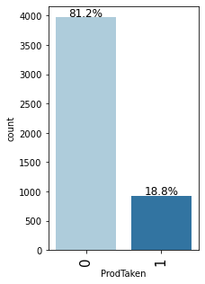

```python
labeled_barplot(data,"ProdTaken",perc=True)
```

Over 80% do no take the product

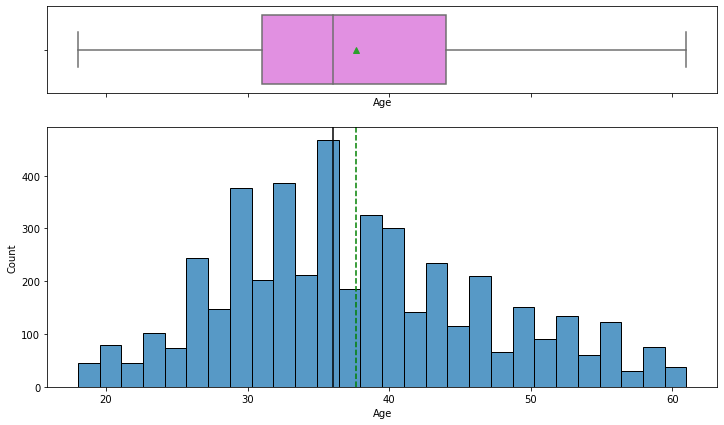

```python
histogram_boxplot(data,'Age')
```

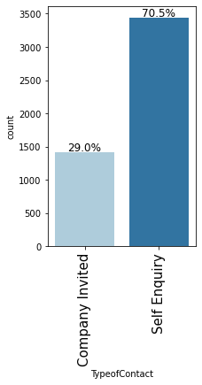

```python
labeled_barplot(data,"TypeofContact",perc=True)
```

Over 70% contacted us

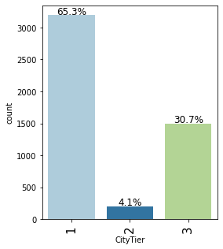

```python
labeled_barplot(data,"CityTier",perc=True)
```

The vast majority are low tier, few are middle, and a good number are high

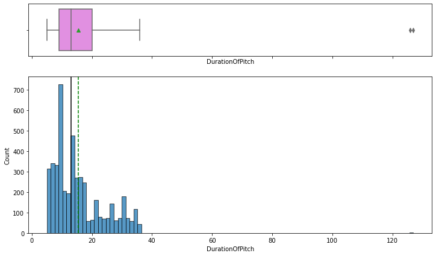

```python
histogram_boxplot(data,'DurationOfPitch')
```

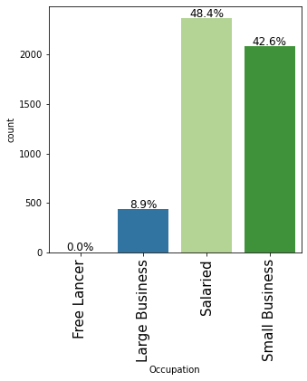

```python
labeled_barplot(data,"Occupation",perc=True)
```

Most customers are slaried or small buisnesses but some are large ones too, very few free lancers exist

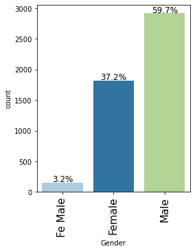

```python
labeled_barplot(data,"Gender",perc=True)
```

Most are male, let's fix the Fe Male part

```python
data['Gender']=data['Gender'].replace('Fe Male','Female')
```

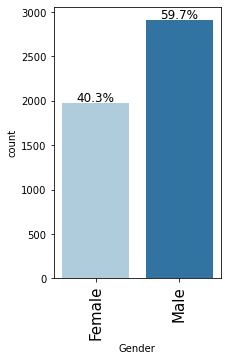

```python
labeled_barplot(data,"Gender",perc=True)
```

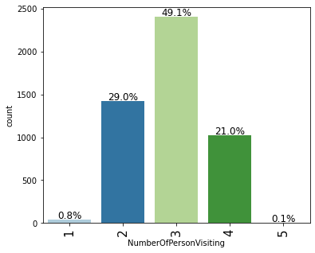

```python
labeled_barplot(data,"NumberOfPersonVisiting",perc=True)
```

Mostly 2-4 people would come, about half the time it was 3, occassionaly 1 or 5 would come

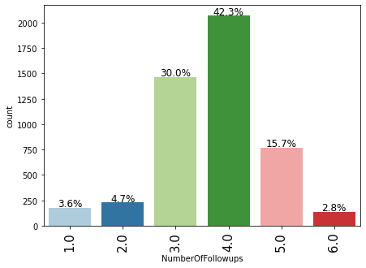

```python
labeled_barplot(data,"NumberOfFollowups",perc=True)
```

Most followed up 4 time, followed by 3 then 5. Only a few followe dup less than 3 or more than 5

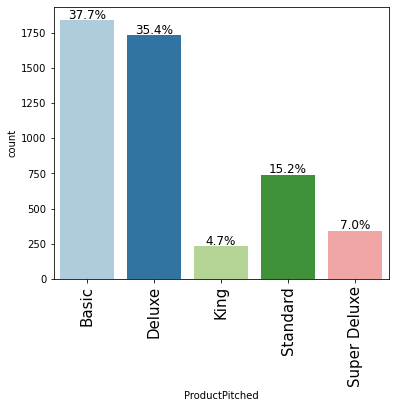

```python
labeled_barplot(data,"ProductPitched",perc=True)
```

Basic and deluxe are very popular

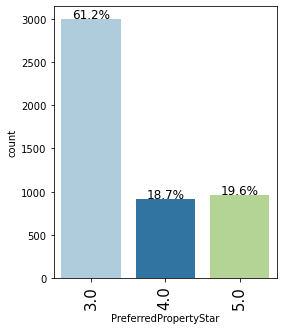

```python
labeled_barplot(data,"PreferredPropertyStar",perc=True)
```

Most people want a 3 star resort though some have higher expectations

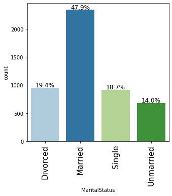

```python
labeled_barplot(data,"MaritalStatus",perc=True)
```

Married is most common. I assume single and unamrried are different, unmarried inclusign those with signifcant others or fiances.

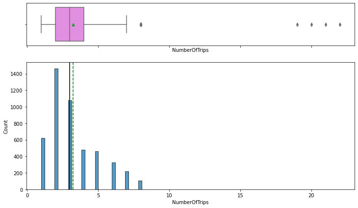

```python
histogram_boxplot(data,'NumberOfTrips')
```

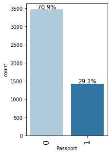

```python
labeled_barplot(data,"Passport",perc=True)
```

Less than 1/3 have passports, this is strange

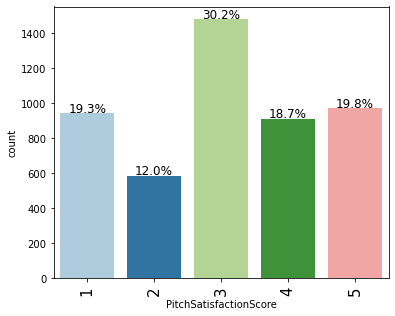

```python
labeled_barplot(data,"PitchSatisfactionScore",perc=True)
```

More or less evenly distirbuted with slighly more people having above than below avrage

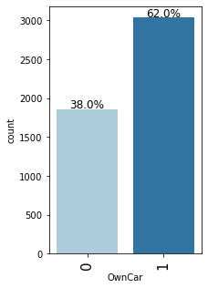

```python
labeled_barplot(data,"OwnCar",perc=True)
```

A good number do not own cars, but most do

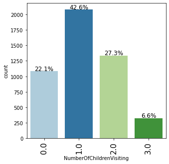

```python
labeled_barplot(data,"NumberOfChildrenVisiting",perc=True)
```

Good spread between 0 and 2, mostly at 1, with some outliers at 3

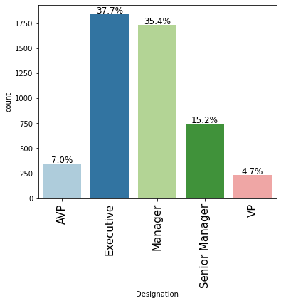

```python
labeled_barplot(data,"Designation",perc=True)
```

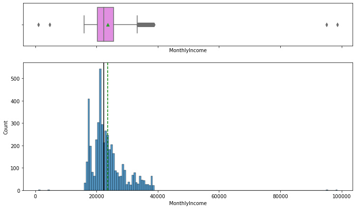

```python
histogram_boxplot(data,'MonthlyIncome')
```

Average is above 20,000 (240,000 a year) so that confirms what we saw above. A lot of outlier, mostly upper bt also lower

Bivariate

Baics

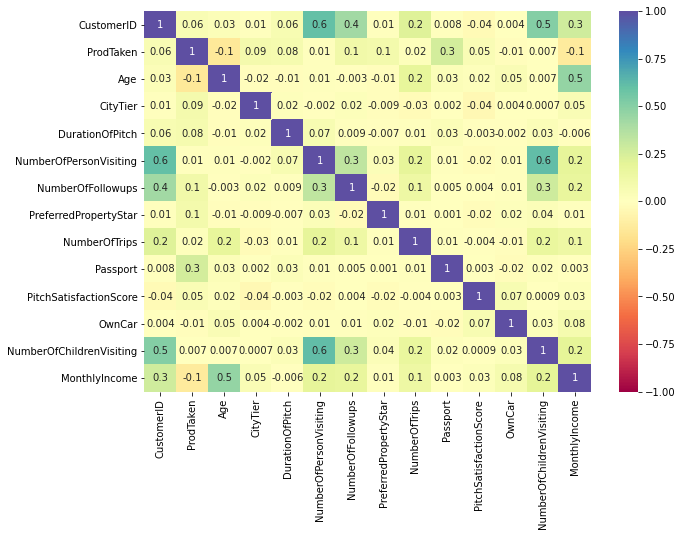

```python
plt.figure(figsize=(10,7))
sns.heatmap(data.corr(),annot=True,vmin=-1,vmax=1,fmt='.1g',cmap="Spectral")
plt.show()
```

high correlations: above 0.5 or below -0.5 Age and monthly income. Numer of chuldren visitng and number of children visitng Good correlation: above 0.3 or below -0.3 Prod taken and passport. Numner of visitor and number of followups.

```python
# function to plot stacked bar chart


def stacked_barplot(data, predictor, target):
    """
    Print the category counts and plot a stacked bar chart

    data: dataframe
    predictor: independent variable
    target: target variable
    """
    count = data[predictor].nunique()
    sorter = data[target].value_counts().index[-1]
    tab1 = pd.crosstab(data[predictor], data[target], margins=True).sort_values(
        by=sorter, ascending=False
    )
    print(tab1)
    print("-" * 120)
    tab = pd.crosstab(data[predictor], data[target], normalize="index").sort_values(
        by=sorter, ascending=False
    )
    tab.plot(kind="bar", stacked=True, figsize=(count + 5, 6))
    plt.legend(
        loc="lower left", frameon=False,
    )
    plt.legend(loc="upper left", bbox_to_anchor=(1, 1))
    plt.show()
```

Let's look at prod taken

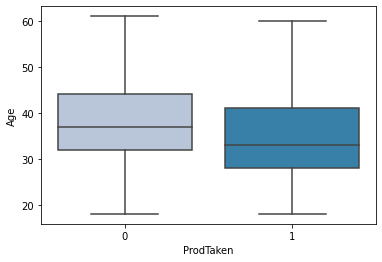

```python
sns.boxplot(data['ProdTaken'],data['Age'],palette="PuBu")
```

Slight change (younger more likely maybe) but nothing of note.

```
ProdTaken           0    1   All
TypeofContact
All              3946  917  4863
Self Enquiry     2837  607  3444
Company Invited  1109  310  1419
------------------------------------------------------------------------------------------------------------------------
```

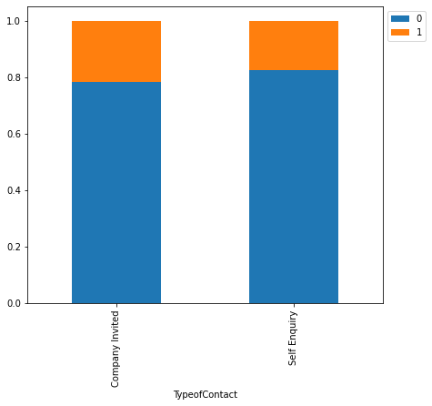

```python
stacked_barplot(data, "TypeofContact", "ProdTaken")
```

It seems that those invited will be more liely to take, though only lightly

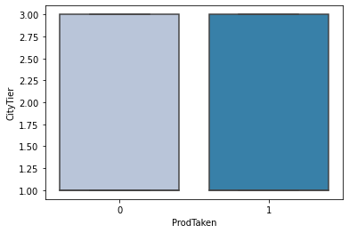

```python
sns.boxplot(data['ProdTaken'],data['CityTier'],palette="PuBu")
```

No difference

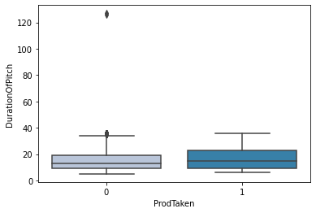

```python
sns.boxplot(data['ProdTaken'],data['DurationOfPitch'],palette="PuBu")
```

Not a whole lot, but all outliers are for not taken and are above. So maybe do have a limit to call time

```
ProdTaken          0    1   All
Occupation
All             3968  920  4888
Salaried        1954  414  2368
Small Business  1700  384  2084
Large Business   314  120   434
Free Lancer        0    2     2
------------------------------------------------------------------------------------------------------------------------
```

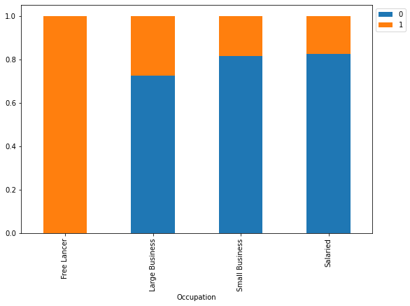

```python
stacked_barplot(data, "Occupation", "ProdTaken")
```

those wokring in large buisness seem more slighly likely to accept than those wokring insmall or salried. All frelancer accpeted, but there are few of them so not important

```
ProdTaken     0    1   All
Gender
All        3968  920  4888
Male       2338  578  2916
Female     1630  342  1972
------------------------------------------------------------------------------------------------------------------------
```

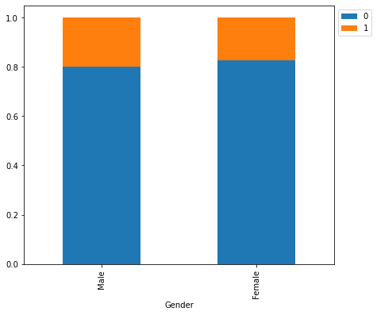

```python
stacked_barplot(data, "Gender", "ProdTaken")
```

Men seem slighly more likely to accept compared to women

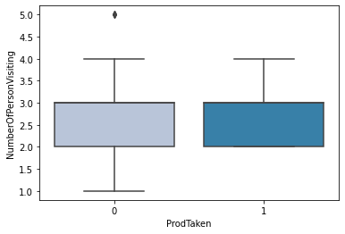

```python
sns.boxplot(data['ProdTaken'],data['NumberOfPersonVisiting'],palette="PuBu")
```

Those that did not accpet had a wider range

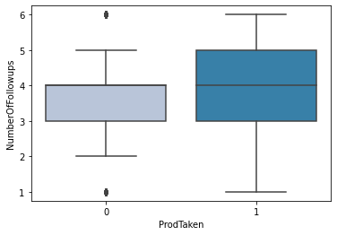

```python
sns.boxplot(data['ProdTaken'],data['NumberOfFollowups'],palette="PuBu")
```

Those that accpted had more vaiery not no reall difference

```
ProdTaken          0    1   All
ProductPitched
All             3968  920  4888
Basic           1290  552  1842
Deluxe          1528  204  1732
Standard         618  124   742
King             210   20   230
Super Deluxe     322   20   342
------------------------------------------------------------------------------------------------------------------------
```

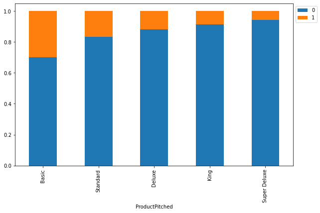

```python
stacked_barplot(data, "ProductPitched", "ProdTaken")
```

Basic and standard are mor likely to be accepted. It seems the more "exlcusive" the worse the chance of accpetance

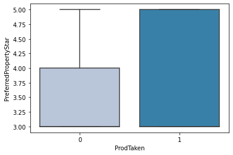

```python
sns.boxplot(data['ProdTaken'],data['PreferredPropertyStar'],palette="PuBu")
```

Fewer who wanted 5 refused but it still happened

```
ProdTaken         0    1   All
MaritalStatus
All            3968  920  4888
Married        2014  326  2340
Single          612  304   916
Unmarried       516  166   682
Divorced        826  124   950
------------------------------------------------------------------------------------------------------------------------
```

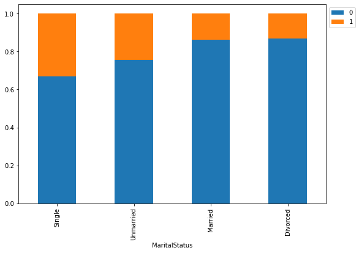

```python
stacked_barplot(data, "MaritalStatus", "ProdTaken")
```

Single then unmarried are more likely to accept

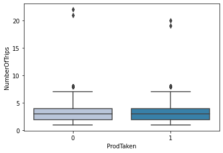

```python
sns.boxplot(data['ProdTaken'],data['NumberOfTrips'],palette="PuBu")
```

No real difference

```
ProdTaken     0    1   All
Passport
All        3968  920  4888
1           928  494  1422
0          3040  426  3466
------------------------------------------------------------------------------------------------------------------------
```

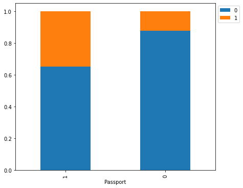

```python
stacked_barplot(data, "Passport", "ProdTaken")
```

Those with paspsorts are more likely to travel

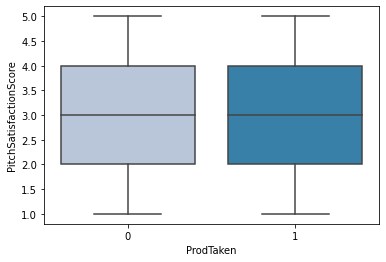

```python
sns.boxplot(data['ProdTaken'],data['PitchSatisfactionScore'],palette="PuBu")
```

No difference

```
ProdTaken     0    1   All
OwnCar
All        3968  920  4888
1          2472  560  3032
0          1496  360  1856
------------------------------------------------------------------------------------------------------------------------
```

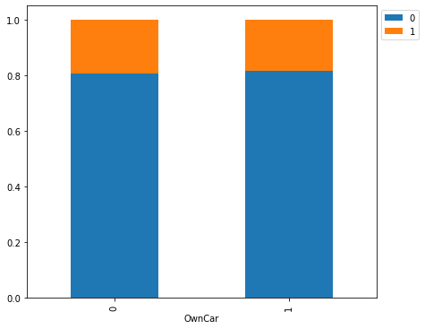

```python
stacked_barplot(data, "OwnCar", "ProdTaken")
```

No real difference

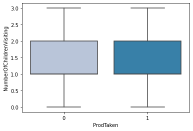

```python
sns.boxplot(data['ProdTaken'],data['NumberOfChildrenVisiting'],palette="PuBu")
```

No difference

```
ProdTaken          0    1   All
Designation
All             3968  920  4888
Executive       1290  552  1842
Manager         1528  204  1732
Senior Manager   618  124   742
AVP              322   20   342
VP               210   20   230
------------------------------------------------------------------------------------------------------------------------
```

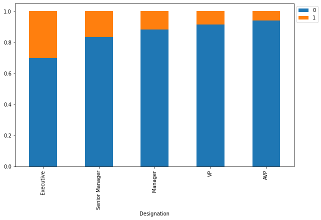

```python
stacked_barplot(data, "Designation", "ProdTaken")
```

Executives have high acceptanc AVP have low (senior also high)

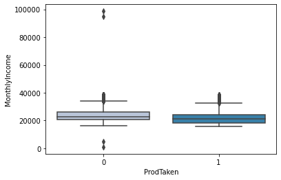

```python
sns.boxplot(data['ProdTaken'],data['MonthlyIncome'],palette="PuBu")
```

THose making more may be slightly less likely to take, though it is very slight if it exists.

For type of package

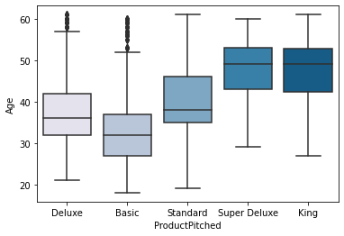

```python
sns.boxplot(data['ProductPitched'],data['Age'],palette="PuBu")
```

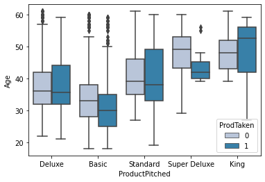

```python
sns.boxplot(data['ProductPitched'],data['Age'],hue=data['ProdTaken'],palette="PuBu")
```

Deluxe: popular amongst mid 30s to early 40s Basic: popular amonsy late 20s to late 30s Standard: popular amonst late 30s to late 40s SUper deluxe: popular amongst mid 40s to early 50s King:popular amongst mid 40s to early 50s

```
TypeofContact   Company Invited  Self Enquiry   All
ProductPitched
All                        1419          3444  4863
Deluxe                      541          1176  1717
Basic                       516          1316  1832
Standard                    218           524   742
Super Deluxe                 96           246   342
King                         48           182   230
------------------------------------------------------------------------------------------------------------------------
```

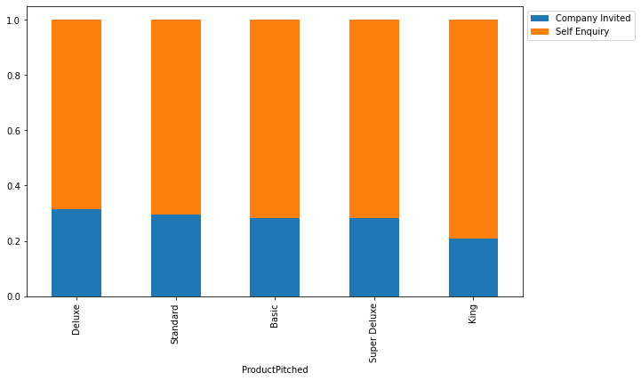

```python
stacked_barplot(data,  "ProductPitched","TypeofContact")
```

King: self inquirty

```
CityTier           1    2     3   All
ProductPitched
All             3190  198  1500  4888
Basic           1466  108   268  1842
Deluxe           908   40   784  1732
King             168   22    40   230
Standard         436   18   288   742
Super Deluxe     212   10   120   342
------------------------------------------------------------------------------------------------------------------------
```

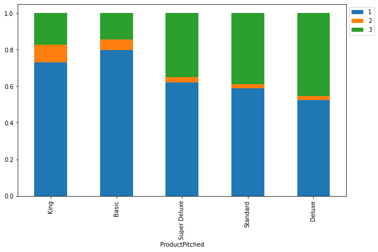

```python
stacked_barplot(data,  "ProductPitched","CityTier")
```

King: 2 Basic: 1 delux:3

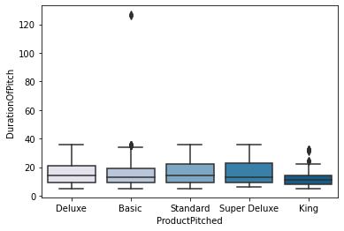

```python
sns.boxplot(data['ProductPitched'],data['DurationOfPitch'],palette="PuBu")
```

Not a lot here

```
Occupation      Free Lancer  Large Business  Salaried  Small Business   All
ProductPitched
Basic                     2             196       924             720  1842
All                       2             434      2368            2084  4888
Deluxe                    0             124       818             790  1732
King                      0              12       114             104   230
Standard                  0              84       338             320   742
Super Deluxe              0              18       174             150   342
------------------------------------------------------------------------------------------------------------------------
```

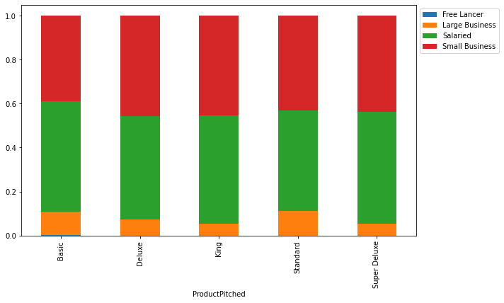

```python
stacked_barplot(data, "ProductPitched","Occupation")
```

Nothing really notable here

```
Gender          Female  Male   All
ProductPitched
All               1972  2916  4888
Deluxe             724  1008  1732
Basic              680  1162  1842
Standard           326   416   742
Super Deluxe       160   182   342
King                82   148   230
------------------------------------------------------------------------------------------------------------------------
```

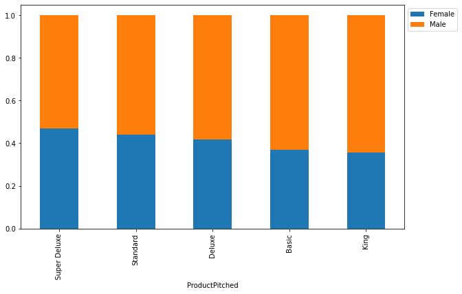

```python
stacked_barplot(data,  "ProductPitched","Gender")
```

Super Deluxe: female King: male

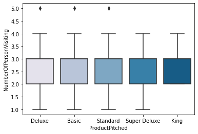

```python
sns.boxplot(data['ProductPitched'],data['NumberOfPersonVisiting'],palette="PuBu")
```

No differences expect king won't habe below 2

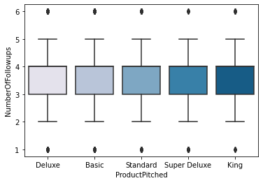

```python
sns.boxplot(data['ProductPitched'],data['NumberOfFollowups'],palette="PuBu")
```

No difference

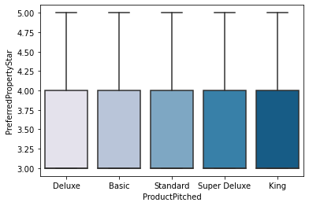

```python
sns.boxplot(data['ProductPitched'],data['PreferredPropertyStar'],palette="PuBu")
```

No difference

```
MaritalStatus   Divorced  Married  Single  Unmarried   All
ProductPitched
All                  950     2340     916        682  4888
Deluxe               336      852     221        323  1732
Basic                332      816     511        183  1842
Standard             142      380      50        170   742
Super Deluxe          88      166      82          6   342
King                  52      126      52          0   230
------------------------------------------------------------------------------------------------------------------------
```

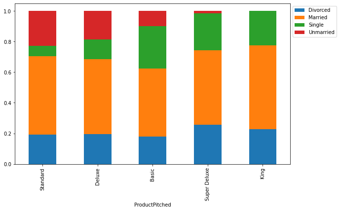

```python
stacked_barplot(data, "ProductPitched","MaritalStatus")
```

Basic:single people Standard:unmarried Deluxe: unmarried and single Super deluxe: divorced KingL anyone other that unmarried

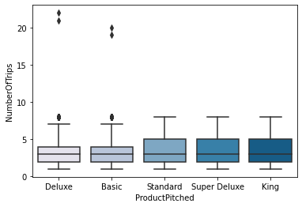

```python
sns.boxplot(data['ProductPitched'],data['NumberOfTrips'],palette="PuBu")
```

No difference

```
Passport           0     1   All
ProductPitched
All             3466  1422  4888
Basic           1274   568  1842
Deluxe          1252   480  1732
Standard         532   210   742
Super Deluxe     238   104   342
King             170    60   230
------------------------------------------------------------------------------------------------------------------------
```

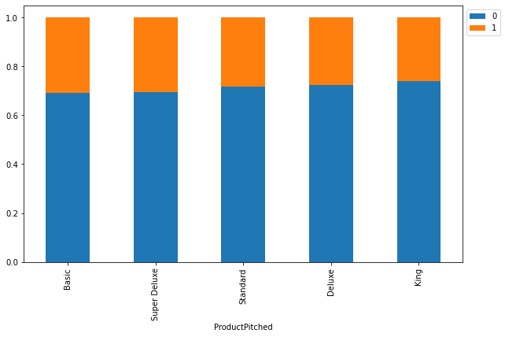

```python
stacked_barplot(data, "ProductPitched","Passport")
```

No difference

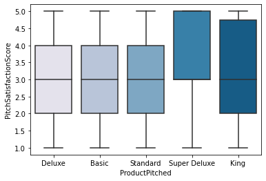

```python
sns.boxplot(data['ProductPitched'],data['PitchSatisfactionScore'],palette="PuBu")
```

Super deluxe: slight increase

```
OwnCar             0     1   All
ProductPitched
All             1856  3032  4888
Basic            758  1084  1842
Deluxe           674  1058  1732
Standard         258   484   742
Super Deluxe     102   240   342
King              64   166   230
------------------------------------------------------------------------------------------------------------------------
```

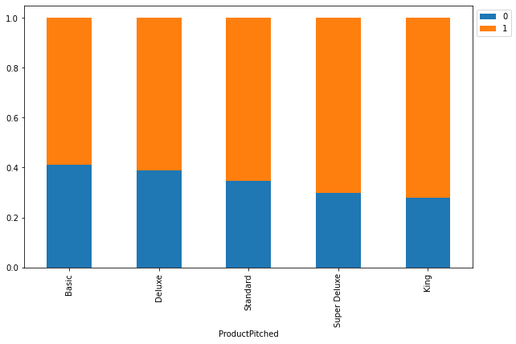

```python
stacked_barplot(data, "ProductPitched","OwnCar")
```

Basic: no king:yes

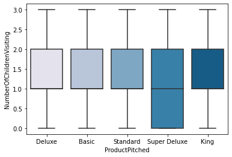

```python
sns.boxplot(data['ProductPitched'],data['NumberOfChildrenVisiting'],palette="PuBu")
```

Nothing other than higher vairance in S deluxe

```
Designation     AVP  Executive  Manager  Senior Manager   VP   All
ProductPitched
King              0          0        0               0  230   230
All             342       1842     1732             742  230  4888
Basic             0       1842        0               0    0  1842
Deluxe            0          0     1732               0    0  1732
Standard          0          0        0             742    0   742
Super Deluxe    342          0        0               0    0   342
------------------------------------------------------------------------------------------------------------------------
```

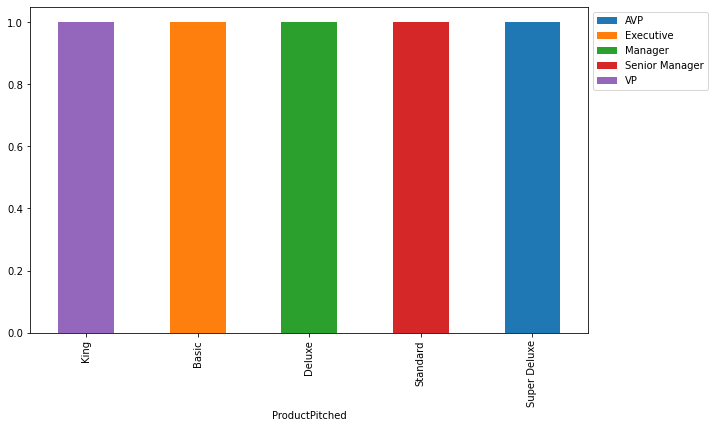

```python
stacked_barplot(data, "ProductPitched","Designation")
```

King: all vp basic: all executive deluxe: all manager standar: all senior manager super deluxe: all avp

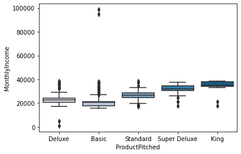

```python
sns.boxplot(data['ProductPitched'],data['MonthlyIncome'],palette="PuBu")
```

Basic: lowest (18,000 or so) but high variance standard: 30,000 or so deluxe: 21,000 or so super deluxe: 35,000 or so kind: 40,00o or so

Basic: all executives, can't drive, late 20s-30s, making 18,000, from tier one cities Standard:all senior manages who are unmarried late 30-40s Deluxe: mid 30s to early 40s, tier 3 city, unmarried and single, all managers, 21,000 monthly income super deluxe:popular amongst mid 40s to early 50s, female, divorced, all avp, 35,000 income King: popular amongst mid 40s to early 50s, self inquiry, city level 2, male, at least 2 people, anyone other than unmarried, own a car, all vps, 40,0000 income I want to see income vs deisgnation

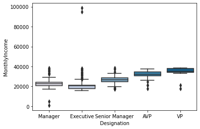

```python
sns.boxplot(data['Designation'],data['MonthlyIncome'],palette="PuBu")
```

Executives make the least and VPs the most

Illustrate the insights based on EDA Key meaningful observations on individual variables and the relationship between variables Individual: Over 80% do no take the product Over 70% contacted us The vast majority are from low tier cities, few are middle, and a good number are high Calls are mostly clustered below about 15-20 minutes but there are outliers above this, so some calls are long. None are above about 38 so there may be a cutoff time . Most customers are salaried or small businesses but some are large ones too, very few free lancers exist Most are male Basic and deluxe are very popular Married is most common. Less than 1/3 have passports, this is strange Average is above 20,000 (240,000 a year) so that confirms what we saw above. A lot of outlier, mostly upper but also lower

Plural high correlations: above 0.5 or below -0.5 Age and monthly income. Number of children visiting and number of children visiting Good correlation: above 0.3 or below -0.3 Prod taken and passport. Number of visitor and number of follow up. It seems that those invited will be more likely to take, though only lightly those working in large business seem more slightly likely to accept than those working in small or salaried. All freelancer accepted, but there are few of them so not important Basic and standard are mor likely to be accepted. It seems the more "exclusive" the worse the chance of acceptance Single then unmarried are more likely to accept Those with passports are more likely to travel Executives have high acceptance AVP have low (senior also high) King: all vp basic: all executive deluxe: all manager standar: all senior manager super deluxe: all avp Executives make the least and VPs the most

Packages (repeated) Basic: all executives, can't drive, late 20s-30s, making 18,000, from tier one cities Standard:all senior manages who are unmarried late 30-40s Deluxe: mid 30s to early 40s, tier 3 city, unmarried and single, all managers, 21,000 monthly income super deluxe:popular amongst mid 40s to early 50s, female, divorced, all avp, 35,000 income King: popular amongst mid 40s to early 50s, self inquiry, city level 2, male, at least 2 people, anyone other than unmarried, own a car, all vps, 40,0000 income I want to see income vs deisgnation

Data Pre-processing

- Prepare the data for analysis - Missing value Treatment, - Outlier Detection(treat, if needed- why or why not ), - Feature Engineering, - Prepare data for modeling

```python
data.isnull().sum().sort_values(ascending=False)
```

```
DurationOfPitch             251
MonthlyIncome               233
Age                         226
NumberOfTrips               140
NumberOfChildrenVisiting     66
NumberOfFollowups            45
PreferredPropertyStar        26
TypeofContact                25
Designation                   0
OwnCar                        0
PitchSatisfactionScore        0
Passport                      0
CustomerID                    0
MaritalStatus                 0
ProdTaken                     0
NumberOfPersonVisiting        0
Gender                        0
Occupation                    0
CityTier                      0
ProductPitched                0
dtype: int64
```

Replace duration, income, and age with mean as they are continious value

```python
cols_to_mean=["DurationOfPitch","MonthlyIncome","Age"]
for colname in cols_to_mean:
    data[colname].fillna(data[colname].mean(), inplace=True)  # mean imputation
```

```python
data.isnull().sum().sort_values(ascending=False)
```

```
NumberOfTrips               140
NumberOfChildrenVisiting     66
NumberOfFollowups            45
PreferredPropertyStar        26
TypeofContact                25
CustomerID                    0
Designation                   0
OwnCar                        0
PitchSatisfactionScore        0
Passport                      0
MaritalStatus                 0
ProductPitched                0
ProdTaken                     0
NumberOfPersonVisiting        0
Gender                        0
Occupation                    0
DurationOfPitch               0
CityTier                      0
Age                           0
MonthlyIncome                 0
dtype: int64
```

That worked, replace all numeric non conitnious value with median. This will be number of trips, children visitng, followups, and prefered states

```python
cols_to_median=["NumberOfTrips","NumberOfChildrenVisiting","NumberOfFollowups","PreferredPropertyStar"]
for colname in cols_to_median:
    data[colname].fillna(data[colname].median(), inplace=True)  # median imputation
```

```python
data.isnull().sum().sort_values(ascending=False)
```

```
TypeofContact               25
CustomerID                   0
PreferredPropertyStar        0
Designation                  0
NumberOfChildrenVisiting     0
OwnCar                       0
PitchSatisfactionScore       0
Passport                     0
NumberOfTrips                0
MaritalStatus                0
ProductPitched               0
ProdTaken                    0
NumberOfFollowups            0
NumberOfPersonVisiting       0
Gender                       0
Occupation                   0
DurationOfPitch              0
CityTier                     0
Age                          0
MonthlyIncome                0
dtype: int64
```

Type of contatc is non numeirc, mode is best

```python
data["TypeofContact"].fillna("Self Enquiry", inplace=True)  # mode imputation
```

```python
data.isnull().sum().sort_values(ascending=False)
```

```
CustomerID                  0
ProdTaken                   0
Designation                 0
NumberOfChildrenVisiting    0
OwnCar                      0
PitchSatisfactionScore      0
Passport                    0
NumberOfTrips               0
MaritalStatus               0
PreferredPropertyStar       0
ProductPitched              0
NumberOfFollowups           0
NumberOfPersonVisiting      0
Gender                      0
Occupation                  0
DurationOfPitch             0
CityTier                    0
TypeofContact               0
Age                         0
MonthlyIncome               0
dtype: int64
```

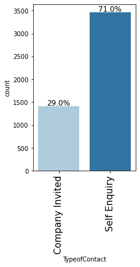

```python
labeled_barplot(data,"TypeofContact",perc=True)
```

Outliers

```python
data.info()#see which are numbers
```

```
<class 'pandas.core.frame.DataFrame'>
RangeIndex: 4888 entries, 0 to 4887
Data columns (total 20 columns):
 #   Column                    Non-Null Count  Dtype
---  ------                    --------------  -----
 0   CustomerID                4888 non-null   int64
 1   ProdTaken                 4888 non-null   int64
 2   Age                       4888 non-null   float64
 3   TypeofContact             4888 non-null   object
 4   CityTier                  4888 non-null   int64
 5   DurationOfPitch           4888 non-null   float64
 6   Occupation                4888 non-null   object
 7   Gender                    4888 non-null   object
 8   NumberOfPersonVisiting    4888 non-null   int64
 9   NumberOfFollowups         4888 non-null   float64
 10  ProductPitched            4888 non-null   object
 11  PreferredPropertyStar     4888 non-null   float64
 12  MaritalStatus             4888 non-null   object
 13  NumberOfTrips             4888 non-null   float64
 14  Passport                  4888 non-null   int64
 15  PitchSatisfactionScore    4888 non-null   int64
 16  OwnCar                    4888 non-null   int64
 17  NumberOfChildrenVisiting  4888 non-null   float64
 18  Designation               4888 non-null   object
 19  MonthlyIncome             4888 non-null   float64
dtypes: float64(7), int64(7), object(6)
memory usage: 763.9+ KB
```

Customer id is probably nor helpful, I will drop

```python
id_customer=data['CustomerID']
data.drop(['CustomerID'], axis=1, inplace=True)
```

```python
data['Age'].mean()
```

```
37.62226512226505
```

```python
data['Age'].median()
```

```
37.0
```

Very close, no need for transform

```python
data['DurationOfPitch'].mean()
```

```
15.490834591330598
```

```python
data['DurationOfPitch'].median()
```

```
14.0
```

That's a little off, but not enough to justify loging it

```python
data['CityTier'].mean()
```

```
1.6542553191489362
```

```python
data['CityTier'].median()
```

```
1.0
```

That is pretty far off, but it is basically categorical, infact let's make it cateogrical not

```python
data["CityTier"] = data["CityTier"].astype('category')
data.dtypes
```

```
ProdTaken                      int64
Age                          float64
TypeofContact                 object
CityTier                    category
DurationOfPitch              float64
Occupation                    object
Gender                        object
NumberOfPersonVisiting         int64
NumberOfFollowups            float64
ProductPitched                object
PreferredPropertyStar        float64
MaritalStatus                 object
NumberOfTrips                float64
Passport                       int64
PitchSatisfactionScore         int64
OwnCar                         int64
NumberOfChildrenVisiting     float64
Designation                   object
MonthlyIncome                float64
dtype: object
```

```python
data['NumberOfPersonVisiting'].mean()
```

```
2.9050736497545007
```

```python
data['NumberOfPersonVisiting'].median()
```

```
3.0
```

Very close

```python
data['NumberOfFollowups'].mean()
```

```
3.711129296235679
```

```python
data['NumberOfFollowups'].median()
```

```
4.0
```

a little skewed, but not enough to transform

```python
data['PreferredPropertyStar'].mean()
```

```
3.577945990180033
```

```python
data['PreferredPropertyStar'].median()
```

```
3.0
```

This is far off, but I would say this should be categorical anyways as we dont have a reason to assum people who prefer 4 or 5 stars are "above" those that prefer 3

```python
data["PreferredPropertyStar"] = data["PreferredPropertyStar"].astype('category')
data.dtypes
```

```
ProdTaken                      int64
Age                          float64
TypeofContact                 object
CityTier                    category
DurationOfPitch              float64
Occupation                    object
Gender                        object
NumberOfPersonVisiting         int64
NumberOfFollowups            float64
ProductPitched                object
PreferredPropertyStar       category
MaritalStatus                 object
NumberOfTrips                float64
Passport                       int64
PitchSatisfactionScore         int64
OwnCar                         int64
NumberOfChildrenVisiting     float64
Designation                   object
MonthlyIncome                float64
dtype: object
```

```python
data['NumberOfTrips'].mean()
```

```
3.229746317512275
```

```python
data['NumberOfTrips'].median()
```

```
3.0
```

Skewed but close

Passport and owncar should already be cateogrical, I will fix thisright after I one hot encode eveything else, we don't want to do it here as they alrady are basically

```python
data = pd.get_dummies(
    data,
    columns=data.select_dtypes(include=["object", "category"]).columns.tolist(),
    drop_first=False,
)
```

```python
data["Passport"] = data["Passport"].astype('category')
data.dtypes
```

```
ProdTaken                           int64
Age                               float64
DurationOfPitch                   float64
NumberOfPersonVisiting              int64
NumberOfFollowups                 float64
NumberOfTrips                     float64
Passport                         category
PitchSatisfactionScore              int64
OwnCar                              int64
NumberOfChildrenVisiting          float64
MonthlyIncome                     float64
TypeofContact_Company Invited       uint8
TypeofContact_Self Enquiry          uint8
CityTier_1                          uint8
CityTier_2                          uint8
CityTier_3                          uint8
Occupation_Free Lancer              uint8
Occupation_Large Business           uint8
Occupation_Salaried                 uint8
Occupation_Small Business           uint8
Gender_Female                       uint8
Gender_Male                         uint8
ProductPitched_Basic                uint8
ProductPitched_Deluxe               uint8
ProductPitched_King                 uint8
ProductPitched_Standard             uint8
ProductPitched_Super Deluxe         uint8
PreferredPropertyStar_3.0           uint8
PreferredPropertyStar_4.0           uint8
PreferredPropertyStar_5.0           uint8
MaritalStatus_Divorced              uint8
MaritalStatus_Married               uint8
MaritalStatus_Single                uint8
MaritalStatus_Unmarried             uint8
Designation_AVP                     uint8
Designation_Executive               uint8
Designation_Manager                 uint8
Designation_Senior Manager          uint8
Designation_VP                      uint8
dtype: object
```

```python
data["OwnCar"] = data["OwnCar"].astype('category')
data.dtypes
```

```
ProdTaken                           int64
Age                               float64
DurationOfPitch                   float64
NumberOfPersonVisiting              int64
NumberOfFollowups                 float64
NumberOfTrips                     float64
Passport                         category
PitchSatisfactionScore              int64
OwnCar                           category
NumberOfChildrenVisiting          float64
MonthlyIncome                     float64
TypeofContact_Company Invited       uint8
TypeofContact_Self Enquiry          uint8
CityTier_1                          uint8
CityTier_2                          uint8
CityTier_3                          uint8
Occupation_Free Lancer              uint8
Occupation_Large Business           uint8
Occupation_Salaried                 uint8
Occupation_Small Business           uint8
Gender_Female                       uint8
Gender_Male                         uint8
ProductPitched_Basic                uint8
ProductPitched_Deluxe               uint8
ProductPitched_King                 uint8
ProductPitched_Standard             uint8
ProductPitched_Super Deluxe         uint8
PreferredPropertyStar_3.0           uint8
PreferredPropertyStar_4.0           uint8
PreferredPropertyStar_5.0           uint8
MaritalStatus_Divorced              uint8
MaritalStatus_Married               uint8
MaritalStatus_Single                uint8
MaritalStatus_Unmarried             uint8
Designation_AVP                     uint8
Designation_Executive               uint8
Designation_Manager                 uint8
Designation_Senior Manager          uint8
Designation_VP                      uint8
dtype: object
```

```python
data = pd.get_dummies(
    data,
    columns=data.select_dtypes(include=["object", "category"]).columns.tolist(),
    drop_first=True, #make sure no objs or cats
)
data.dtypes
```

```
ProdTaken                          int64
Age                              float64
DurationOfPitch                  float64
NumberOfPersonVisiting             int64
NumberOfFollowups                float64
NumberOfTrips                    float64
PitchSatisfactionScore             int64
NumberOfChildrenVisiting         float64
MonthlyIncome                    float64
TypeofContact_Company Invited      uint8
TypeofContact_Self Enquiry         uint8
CityTier_1                         uint8
CityTier_2                         uint8
CityTier_3                         uint8
Occupation_Free Lancer             uint8
Occupation_Large Business          uint8
Occupation_Salaried                uint8
Occupation_Small Business          uint8
Gender_Female                      uint8
Gender_Male                        uint8
ProductPitched_Basic               uint8
ProductPitched_Deluxe              uint8
ProductPitched_King                uint8
ProductPitched_Standard            uint8
ProductPitched_Super Deluxe        uint8
PreferredPropertyStar_3.0          uint8
PreferredPropertyStar_4.0          uint8
PreferredPropertyStar_5.0          uint8
MaritalStatus_Divorced             uint8
MaritalStatus_Married              uint8
MaritalStatus_Single               uint8
MaritalStatus_Unmarried            uint8
Designation_AVP                    uint8
Designation_Executive              uint8
Designation_Manager                uint8
Designation_Senior Manager         uint8
Designation_VP                     uint8
Passport_1                         uint8
OwnCar_1                           uint8
dtype: object
```

```python
data['PitchSatisfactionScore'].mean()
```

```
3.078150572831424
```

```python
data['PitchSatisfactionScore'].median()
```

```
3.0
```

Very close

```python
data['NumberOfChildrenVisiting'].mean()
```

```
1.1847381342062193
```

```python
data['NumberOfChildrenVisiting'].median()
```

```
1.0
```

Slightly off but again nothing to note, also we want there to remain ints so that it is asy to interpret

```python
data['MonthlyIncome'].mean()
```

```
23619.853490869984
```

```python
data['MonthlyIncome'].median()
```

```
22655.0
```

Again nothing to worry about It seems there is no real need for outlier replacement as all of the numeric data is now either very close to being normal or categorical

Model building - Bagging

- Build Bagging classifier, Random Forest, and Decision Tree. - Comment on model performance

```python
def model_performance_classification_sklearn(model, predictors, target):
    """
    Function to compute different metrics to check classification model performance

    model: classifier
    predictors: independent variables
    target: dependent variable
    """

    # predicting using the independent variables
    pred = model.predict(predictors)

    acc = accuracy_score(target, pred)  # to compute Accuracy
    recall = recall_score(target, pred)  # to compute Recall
    precision = precision_score(target, pred)  # to compute Precision
    f1 = f1_score(target, pred)  # to compute F1-score

    # creating a dataframe of metrics
    df_perf = pd.DataFrame(
        {
            "Accuracy": acc,
            "Recall": recall,
            "Precision": precision,
            "F1": f1,
        },
        index=[0],
    )

    return df_perf
```

```python
def confusion_matrix_sklearn(model, predictors, target):
    """
    To plot the confusion_matrix with percentages

    model: classifier
    predictors: independent variables
    target: dependent variable
    """
    y_pred = model.predict(predictors)
    cm = confusion_matrix(target, y_pred)
    labels = np.asarray(
        [
            ["{0:0.0f}".format(item) + "\n{0:.2%}".format(item / cm.flatten().sum())]
            for item in cm.flatten()
        ]
    ).reshape(2, 2)

    plt.figure(figsize=(6, 4))
    sns.heatmap(cm, annot=labels, fmt="")
    plt.ylabel("True label")
    plt.xlabel("Predicted label")
```

```python
X = data.drop('ProdTaken',axis=1)
y = data['ProdTaken']
X_train, X_test, y_train, y_test = train_test_split(X, y, test_size=0.3, random_state=1,stratify=y)
print(X_train.shape, X_test.shape)
```

```
(3421, 38) (1467, 38)
```

```
Training performance:
    Accuracy  Recall  Precision   F1
0       1.0     1.0        1.0  1.0
Testing performance:
    Accuracy    Recall  Precision        F1
0  0.885481  0.634058    0.72314  0.675676
```

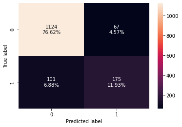

```python
#Fitting the model
d_tree = DecisionTreeClassifier(random_state=1)
d_tree.fit(X_train,y_train)

#Calculating different metrics
dtree_model_train_perf=model_performance_classification_sklearn(d_tree,X_train,y_train)
print("Training performance:\n",dtree_model_train_perf)
dtree_model_test_perf=model_performance_classification_sklearn(d_tree,X_test,y_test)
print("Testing performance:\n",dtree_model_test_perf)
#Creating confusion matrix
confusion_matrix_sklearn(d_tree, X_test, y_test)
```

There are a LOT of false negative tot he point that recall is 63.4%. The stats of the training performance points to over fitting

```
Training performance:
    Accuracy  Recall  Precision   F1
0       1.0     1.0        1.0  1.0
Testing performance:
    Accuracy    Recall  Precision        F1
0  0.920245  0.615942   0.939227  0.743982
```

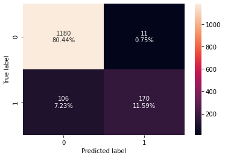

```python
rf_estimator = RandomForestClassifier(random_state=1)
rf_estimator.fit(X_train,y_train)

#Calculating different metrics
rf_estimator_model_train_perf=model_performance_classification_sklearn(rf_estimator,X_train,y_train)
print("Training performance:\n",rf_estimator_model_train_perf)
rf_estimator_model_test_perf=model_performance_classification_sklearn(rf_estimator,X_test,y_test)
print("Testing performance:\n",rf_estimator_model_test_perf)

#Creating confusion matrix
confusion_matrix_sklearn(rf_estimator, X_test, y_test)
```

Accuracy improved but recall got worse. The stats of the training performance points to over fitting

```
Training performance:
    Accuracy    Recall  Precision        F1
0  0.993861  0.968944     0.9984  0.983452
Testing performance:
    Accuracy    Recall  Precision        F1
0  0.904567  0.594203   0.854167  0.700855
```

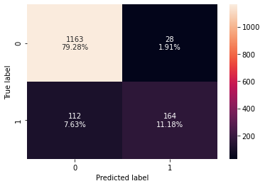

```python
#Fitting the model
bagging_classifier = BaggingClassifier(random_state=1)
bagging_classifier.fit(X_train,y_train)

#Calculating different metrics
bagging_classifier_model_train_perf=model_performance_classification_sklearn(bagging_classifier,X_train,y_train)
print("Training performance:\n",bagging_classifier_model_train_perf)
bagging_classifier_model_test_perf=model_performance_classification_sklearn(bagging_classifier,X_test,y_test)
print("Testing performance:\n",bagging_classifier_model_test_perf)
#Creating confusion matrix
confusion_matrix_sklearn(bagging_classifier, X_test, y_test)
```

Again, very bad recall. The stats of the training performance points to over fitting

Model performance improvement - Bagging

- Comment on which metric is right for model performance evaluation and why? - Comment on the model performance after tuning the Decision Tree, Bagging, and Random Forest classifier to improve the model performance.

**Best way to evaluate model is Testt recall as we want to get as many customers as we can. It is likely we will loose more by not reaching out to those that would buy than hriing people who reach out to those that don't**

tune the tree

```python
#Choose the type of classifier.
dtree_estimator = DecisionTreeClassifier(class_weight={0:0.20,1:0.80},random_state=1)

# Grid of parameters to choose from
parameters = {'max_depth': np.arange(2,10),
              'min_samples_leaf': [5, 7, 10, 15],
              'max_leaf_nodes' : [2, 3, 5, 10,15],
              'min_impurity_decrease': [0.0001,0.001,0.01,0.1]
             }

# Type of scoring used to compare parameter combinations
scorer = metrics.make_scorer(metrics.recall_score)

# Run the grid search
grid_obj = GridSearchCV(dtree_estimator, parameters, scoring=scorer,n_jobs=-1)
grid_obj = grid_obj.fit(X_train, y_train)

# Set the clf to the best combination of parameters
dtree_estimator = grid_obj.best_estimator_

# Fit the best algorithm to the data.
dtree_estimator.fit(X_train, y_train)
```

```
DecisionTreeClassifier(class_weight={0: 0.2, 1: 0.8}, max_depth=5,
                       max_leaf_nodes=15, min_impurity_decrease=0.0001,
                       min_samples_leaf=5, random_state=1)
```

```
Training performance:
    Accuracy    Recall  Precision        F1
0  0.791289  0.661491   0.462039  0.544061
Testing performance:
    Accuracy   Recall  Precision        F1
0  0.790729  0.65942   0.460759  0.542474
```

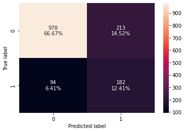

```python
#Calculating different metrics
dtree_estimator_model_train_perf=model_performance_classification_sklearn(dtree_estimator,X_train,y_train)
print("Training performance:\n",dtree_estimator_model_train_perf)
dtree_estimator_model_test_perf=model_performance_classification_sklearn(dtree_estimator,X_test,y_test)
print("Testing performance:\n",dtree_estimator_model_test_perf)
#Creating confusion matrix
confusion_matrix_sklearn(dtree_estimator, X_test, y_test)
```

getting better, recall is up but accuracy is down, we are getting a lot of false positive and stiil many false negatives exist